## Explore

이번 포스트에서는 EDA 패키지인 `explore` 에 대해 소개한다.

`explore` 패키지는 탐색적 데이터 분석(EDA)를 위한 다양한 기능을 제공하는데 제공하는 주요기능은 다음과 같다.

- 단변량, 이변량, 다변량 변수에 대한 대화형 데이터 탐색
- 자동화된 EDA 보고서의 생성
- tidy한 함수를 사용한 수동 데이터 탐색 기능.

### 학업 중단자 데이터 로딩

`explore` 패키지의 기능을 소개하기 위해 사용하는 데이터는 ‘평균과 중간값 등 통계치의 시각화 in R’(https://2stndard.tistory.com/132) 포스트에서 사용했던 학업 중단자 데이터를 사용하도록 하겠다.

```r
df_dropout <- read_excel('데이터저장폴더/유초 주요-04 시도별 행정구역별 교육통계 현황_방통제외(1999-2022)_20220824y.xlsx',
           sheet = '2021-2022',
           skip = 11,
           col_names = FALSE,
           col_types = c(rep('text', 4), rep('numeric', 166)))

df_dropout <- df_dropout |>
  select(1, 2, 3, 4, 22, seq(from = 127, to = 142, by = 3)) |>
  rename(c('연도' = ...1, '시도' = ...2, '시군' = ...3, '학교급' = ...4, '전체학생수' = ...22, '학업중단자' = ...127, '유예' = ...130, '면제' = ...133, '자퇴' = ...136, '퇴학' = ...139, '제적' = ...142))
```

여기에 일부 열을 팩터로 변경하여 사용한다.

```r
df_dropout <- df_dropout  |>
  mutate(시도 = as.factor(시도),
         학교급 = as.factor(학교급))
```

### explore 패키지

우선 `explore` 패키지를 설치한다.

```r
if (!require(explore)) {
  install.packages('explore')
  library(explore)
}
```

### explore()

`explore` 패키지에서 가장 기본적으로 사용되는 함수는 `explore()`이다. 이 함수는 `shiny` 패키지로 개발된 HTML 앱을 사용하여 데이터의 전반적인 구조를 살펴볼 수 있다.

```r
explore(df_dropout)
```

`explore()`를 사용하여 만들어진 앱에서는 변수간의 관계를 살펴볼 수 있는 ‘variable’ 탭, 트리구조로 변수들간의 관계를 설명해주는 ‘explain’ 탭, 해당 변수의 기초 통계치를 보여주는 ‘overview’ 탭, 원천 데이터를 보여주는 ‘data’ 탭의 네 가지 기능을 제공한다.

[figure not shown]

[figure not shown]

[figure not shown]

[figure not shown]

### report()

앞선 `explore()`로 생성한 앱에서 ‘report’ 버튼을 누르면 ’Rmarkdown’으로 생성되는 HTML 리포트가 생성된다. 이 리포트를 생성하는 함수가 `report()`이다.

```r
report(df_dropout, output_dir = getwd(), target = '학교급')
```

[figure not shown]

### explain_tree()

`explain_tree()`는 의사결정 나무를 사용하여 변수간의 관계를 나타내주는 함수이다.

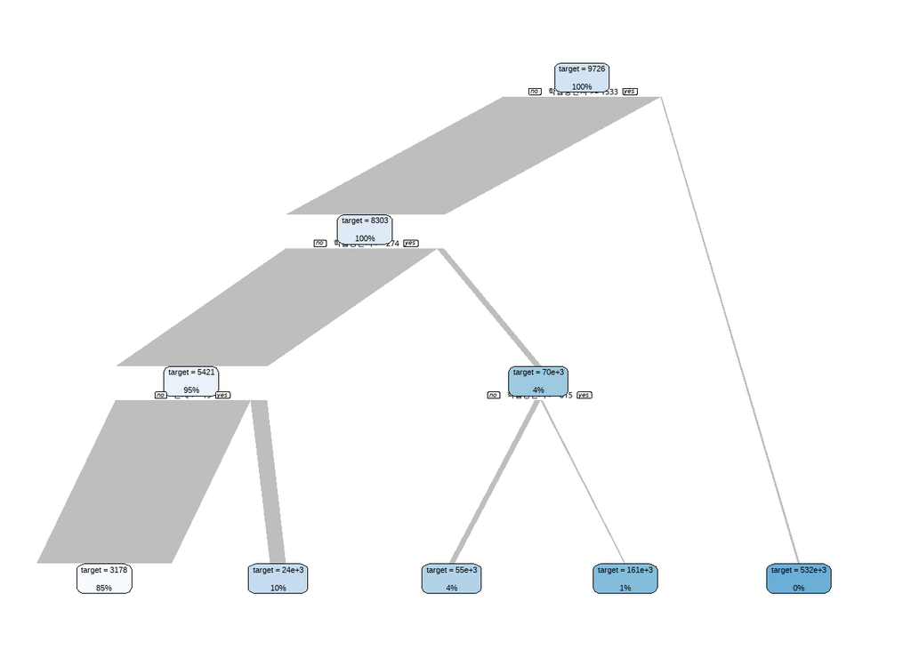

```r
explain_tree(df_dropout, target = '전체학생수')
```

### explore_tbl()

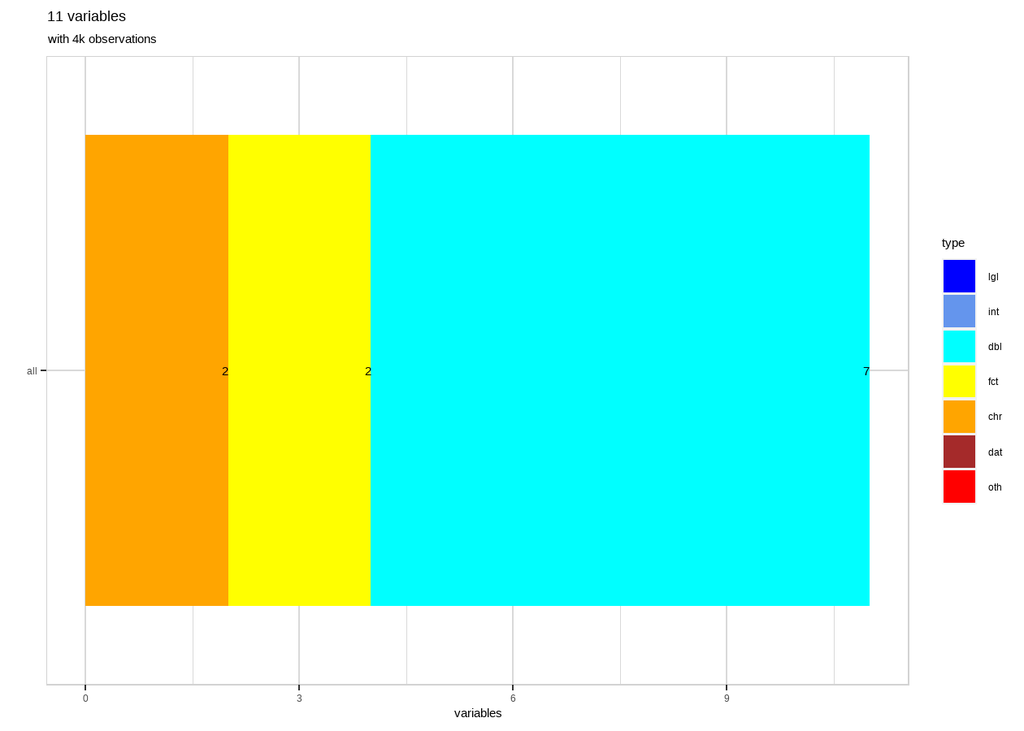

```r
explore_tbl(df_dropout)
```

### describe()

`describe()`는 데이터 변수별로 기초 통계치를 사용하여 전반적인 EDA를 보여준다.

```r
describe(df_dropout)
```

```
## # A tibble: 11 x 8
##    variable   type     na na_pct unique   min    mean     max
##    <chr>      <chr> <int>  <dbl>  <int> <dbl>   <dbl>   <dbl>
##  1 연도       chr       0      0      2    NA   NA         NA
##  2 시도       fct       0      0     17    NA   NA         NA
##  3 시군       chr       0      0    208    NA   NA         NA
##  4 학교급     fct       0      0     13    NA   NA         NA
##  5 전체학생수 dbl       0      0   2999     0 9726.   1656804
##  6 학업중단자 dbl       0      0    399     0   64.9    10385
##  7 유예       dbl       0      0    191     0   15.7     4089
##  8 면제       dbl       0      0    182     0   13.0     2484
##  9 자퇴       dbl       0      0    249     0   35.6     3758
## 10 퇴학       dbl       0      0     21     0    0.54      45
## 11 제적       dbl       0      0     11     0    0.08      11
```